# CASE STUDY 1

Amanda Butler

January 15, 2019

## Background

Your first weekly project requires you to submit a review of 4-5 different data visualizations used to answer specific questions. Some fun websites are wonkblog, fivethiryeight, and priceonomics (but you can use any website, blog, or article with a good visualization).

- Find 4-5 examples of data-driven answers and write a one-paragraph review of each.
- List 2-3 items that are unique/good
- Identify 1 issue with the each example

## Chosen Graphics

### RN Employment in the United States

[Graphic Source](https://priceonomics.com/the-states-with-the-largest-nursing-shortages/)

The image below does a good job at clearly organizing the data into two groups by using different hues. This might not be the best way to represent the data for everyone, given that some may be colorblind. But what I like about this graphic is it took that into consideration by not only changing the color but also changing the direction of the bars by putting them opposite of each other. It is both this change in direction and placement of the different groups (too few nurses being placed only at the top of the graphic) that illustrates that there are two different subgroups within all the United States being observed. The graph even includes arrows to label what the change in direction represents.

My main objection to this graphic other than it doesn’t include numbers or any frame of reference to what the percentages actually represent, is the stacking of the bars. It is hard to compare the bars representing “too few nurses” to those below it because they are not right next to each other. It does redeem itself a little by having the percentage next to it, but the comparison would be more clear if they were on top of each other. Also I find the distance between the bars and their state labels to be too far apart, making it hard to tell which state gets what percentage. If the reader cannot tell what state the data is connected to, the graphic is not very effective in communicating what it is trying to communicate here.

[figure not shown]

### NFL Fans in the U.S.

[Graphic Source](https://priceonomics.com/where-do-nfl-fans-live-mapping-football-fandom/)

This image of the NFL Fans in the United States, organized by specific team does a good job at showing different colors and is interactive, so you can find and select each area to know what the colors mean. At first glance, although a little overwhelming with so many colors, we can tell that those who like their team typically stay in one area. This graphic is large enough which makes it fairly easy for the viewer to detect the different colors of each area and identify them with the included labels.

My biggest issue with this graphic is in what it is communicating.I feel that for such a big graphic it really doesn’t show much information. It is difficult to compare fans from one area to another area because there are so many groups that are only included on one part of the graph. This could be fixed by only focusing on representing fans from a few selected teams. This graphical representation of the United States also does not take into consideration the effects of the population size like the electoral college does. The colored regions can show area, but it is an inaccurate comparison of the number of fans in places like Montana or Idaho to small populated states like New York or Massachusetts. The more amount of color on the graph could be misleading viewers into thinking the less populated but bigger regions have more fans than those in the small regions.

[figure not shown]

### Why Do Companies Move Offices?

[Graphic Source](https://priceonomics.com/why-do-companies-move-offices/)

I picked this graph because it was pretty simple looking. It wants to communicate something it feels is important, the most common reasons companies move their offices, but doesn’t do so in a flashy way or misleading way. I like that this graphic is only looking at a few groups or reasons companies move and the percentages are written above the bars, so the viewers don’t have to guess. The reasons for moving are also shown in descending order, making it easy to identify the number one reason and so forth.

I do wish this graphic had a little more information like how many companies and what types were surveyed. It would be good to have a frame of reference to know if about half the companies represented as moving due to growth here is actually from a large sample and not just due to 5 out of 10 surveyed companies. It might also be good to know information to give this data more context like how often companies move to begin with. Overall, this is a good graphic for a simple question, but if it wanted to answer the question they wish to answer more effectively they should include a little more information in their graphic while still keeping it simple.

[figure not shown]

### Growth of the Internet of Things

[Graphic Source](https://priceonomics.com/the-iot-data-explosion-how-big-is-the-iot-data/)

This last graphic does a good job at including the numerical value of the growth helping us understand what it is trying to communicate quite well. It does as John Rauser says, “make new ideas appear in the heads of other people”. We just have to take one look at this and see that over the last 6-7 years the internet has been embedded in our things by the billions and is steadily increasing. It has a good title and subtitle, is ascetically pleasing and yet it’s also simple.

The graph and title is a little misleading as it includes data for a time period that has not occurred yet. The title could say “Projected Growth in the Internet of Things Devices” if that’s what it wanted to focus on. It could also use a y-axis scale, even though it is very well labeled on both axis. Something this graph could add is to see what types of IoT devices are growing over time. Is it just all of the IoT devices collectively growing in their usage or is there one particular device that is growing more rapidly than the others? Graphics can be simple and still answer include all the necessary information to communicate what they want to communicate.

[figure not shown]

## Code Snippet

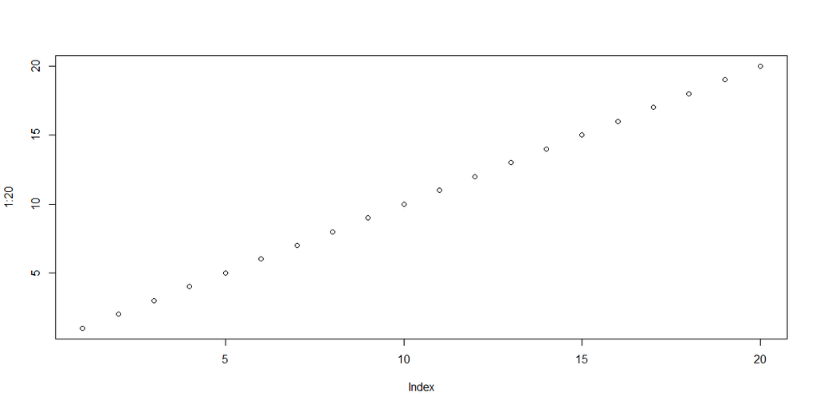

```r
plot(1:20)
```